# Predict POC values from env, using nested CV

Train a XGBoost model to predict POC values from environmental data used in Wang et al., 2023.

Author

Thelma Panaïotis

## Set-up and load data

```r
source("utils.R")
load("data/04.all_data.Rdata")
output_filename <- "data/08.all_preds_poc_from_env_nested_cv.Rdata"
```

## Data transformation

```r
df <- df %>% mutate(poc_log = log(poc))
df_sf <- st_as_sf(df, coords = c("lon", "lat"), crs = 4326)
```

```r
# Explanatory variables
exp_vars <- df %>%
  select(
    temperature,
    phosphate,
    silicate,
    alkalinity,
    dic,
    npp,
    oxygen
  ) %>%
  colnames()
```

## Data split

To better assess the performance of our model and get a distribution of R² instead of a single value, we will use nested cross-validation.

Instead of splitting the data into train and test sets and get a single estimate of R² on the test set, we will use nested cross-validation so that we have several repeats of train/test splits and thus a distribution of R² values. For each fold, a second cross-validation is performed within the training set in order to tune the hyperparameters.

We use 10-fold cross-validation:

- 10% of data for testing
- 90% of data for training. This subset is used for nested cross-validation with:
  - 10% of data for validation
  - 90% of data for learning

Two different methods for data splitting are used:

- stratified on deciles of the response variable (`poc_log`)
- spatial cross-validation using blocks

```r
set.seed(seed)
# Bind together folds of both nested_cv
folds <- bind_rows(
  # Stratified CV on deciles of response variable
  nested_cv(
    df,
    outside = vfold_cv(v = 10, strata = poc_log, breaks = 9),
    inside = vfold_cv(v = 10, strata = poc_log, breaks = 9)) %>%
    mutate(cv_type = "stratified"),
  # Spatial CV
  nested_cv(
    df_sf,
    outside = spatial_block_cv(v = 10),
    inside = spatial_block_cv(v = 10)) %>%
    mutate(cv_type = "spatial")
)
```

## Model definition

Let’s define a XGBoost regression model, with tunable hyperparameters:

- `trees`: number of trees
- `tree_depth`: maximum depth (i.e. number of splits) in a tree
- `min_n`: minimum number of objects in a node to split further
- `learn_rate`

```r
# Define a xgboost model with hyperparameters to tune
xgb_spec <- boost_tree(
  trees = tune(),
  tree_depth = tune(),
  min_n = tune(),
  learn_rate = tune()
) %>%
  set_mode("regression") %>%
  set_engine("xgboost")
```

We also generate the formula from the explanatory variables.

```r
# Generate formula from list of explanatory variables
xgb_form <- as.formula(paste("poc_log ~ ", paste(c("poc", exp_vars), collapse = " + "), sep = ""))
```

Finally, let’s define the grid for the gridsearch (only one grid is used for all folds).

```r
# Define one grid for all folds
set.seed(seed)
xgb_grid <- grid_latin_hypercube(
  trees(),
  learn_rate(),
  tree_depth(),
  min_n(),
  size = 30
)
```

## Models fitting

Let’s loop on cv folds. For each fold, a gridsearch is performed using nested CV on training data, and performance are assessed on the test data. This is run in parallel on 10 cores.

```r
res <- mclapply(1:nrow(folds), function(i){
  ## Get fold
  x <- folds[i,]

  ## Train and test sets
  df_train <- analysis(x$splits[[1]]) %>% as_tibble()
  df_test <- assessment(x$splits[[1]]) %>% as_tibble()

  ## Recipe
  xgb_rec <- recipe(xgb_form, data = df_train) %>%
    update_role(poc, new_role = "untransformed outcome")

  ## Workflow
  xgb_wflow <- workflow() %>%
    add_recipe(xgb_rec) %>%
    add_model(xgb_spec)


  ## Gridsearch
  set.seed(seed)
  xgb_res <- tune_grid(
    xgb_wflow,
    resamples = x$inner_resamples[[1]],
    grid = xgb_grid,
    metrics = metric_set(rmse),
    control = control_grid(save_pred = TRUE)
  )
  best_params <- select_best(xgb_res)

  ## Final fit
  final_xgb <- finalize_workflow(
    xgb_wflow,
    best_params
  )
  final_res <- fit(final_xgb, df_train)

  ## Prediction on outer folds
  preds <- predict(final_res, new_data = df_test) %>%
    bind_cols(df_test %>% select(poc_log))

  ## Model explainer
  # Select only predictors
  vip_train <- xgb_rec %>% prep() %>% bake(new_data = NULL, all_predictors())

  # Explainer
  xgb_explain <- explain_tidymodels(
      model = extract_fit_parsnip(final_res),
      data = vip_train,
      y = df_train %>%  pull(poc_log),
      verbose = FALSE
    )

  # Variable importance
  full_vip <- model_parts(xgb_explain) %>%
    bind_rows() %>%
    filter(variable != "_baseline_")

  # CP profiles
  cp_profiles <- lapply(exp_vars, function(my_var){
    model_profile(explainer = xgb_explain, variables = my_var)$cp_profiles %>% as_tibble()
  }) %>%
    bind_rows()

  ## Return results
  return(tibble(
    preds = list(preds),
    importance = list(full_vip),
    cp_profiles = list(cp_profiles),
    fold = x$id,
    cv_type = x$cv_type))
}, mc.cores = 10) %>%
  bind_rows()
```

## Models evaluation

### Rsquares

```r
# Unnest predictions
preds <- res %>% select(fold, cv_type, preds) %>% unnest(preds)

# Compute Rsquare for each fold of each CV type
rsquares <- preds %>%
  group_by(cv_type, fold) %>%
  rsq(truth = poc_log, estimate = .pred)

# Distribution of Rsquares by CV type
rsquares %>% split(.$cv_type) %>% map(summary)
```

```
$spatial
   cv_type              fold             .metric           .estimator
 Length:10          Length:10          Length:10          Length:10
 Class :character   Class :character   Class :character   Class :character
 Mode  :character   Mode  :character   Mode  :character   Mode  :character



   .estimate
 Min.   :0.5227
 1st Qu.:0.6024
 Median :0.7455
 Mean   :0.7033
 3rd Qu.:0.7921
 Max.   :0.8467

$stratified
   cv_type              fold             .metric           .estimator
 Length:10          Length:10          Length:10          Length:10
 Class :character   Class :character   Class :character   Class :character
 Mode  :character   Mode  :character   Mode  :character   Mode  :character



   .estimate
 Min.   :0.8125
 1st Qu.:0.8618
 Median :0.8872
 Mean   :0.8838
 3rd Qu.:0.9060
 Max.   :0.9403
```

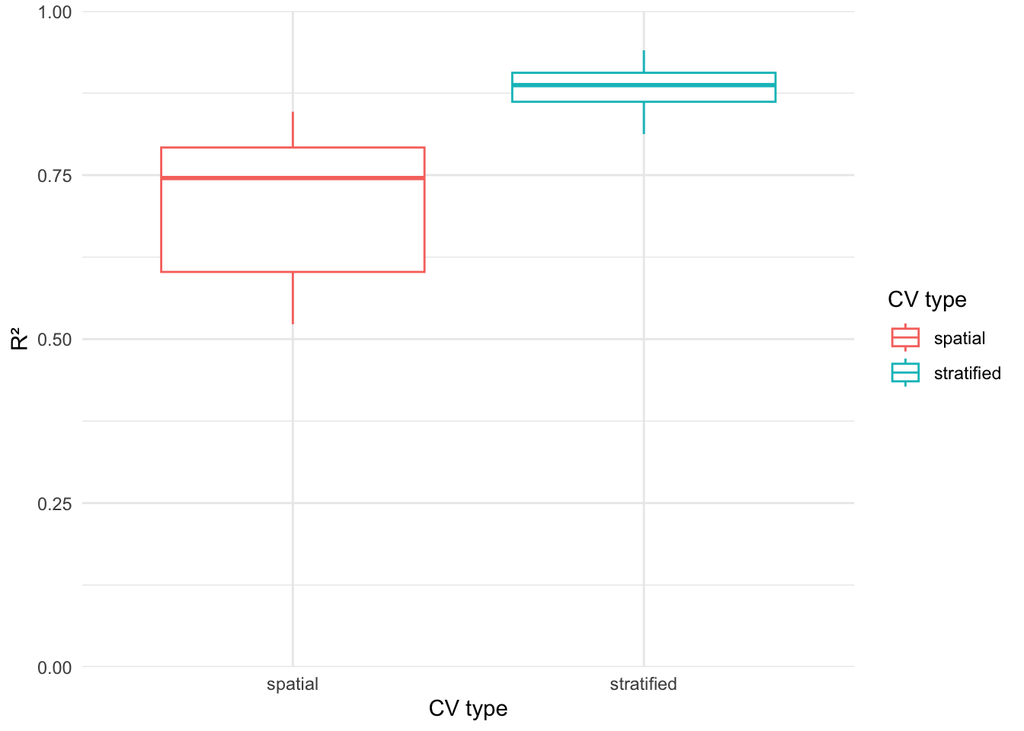

```r
# Plot Rsquares values
ggplot(rsquares) +
  geom_boxplot(aes(x = cv_type, y = .estimate, group = cv_type, colour = cv_type)) +
  scale_y_continuous(limits = c(0, 1), expand = c(0, 0)) +
  labs(x = "CV type", y = "R²", colour = "CV type")
```

### Predictions VS truth

Plot pred VS truth on the test part of each fold of each CV type.

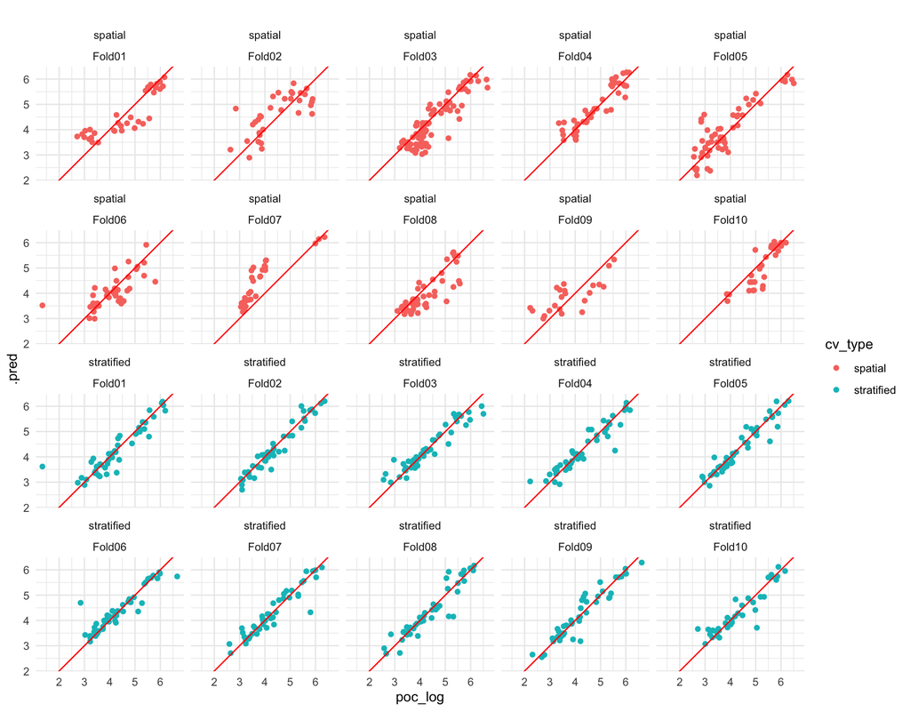

```r
preds %>%
  ggplot() +
  geom_point(aes(x = poc_log, y = .pred, colour = cv_type)) +
  geom_abline(intercept = 0, slope = 1, colour = "red") +
  coord_fixed() +
  facet_wrap(cv_type~fold)
```

Now let’s focus on a representative fold for each CV type.

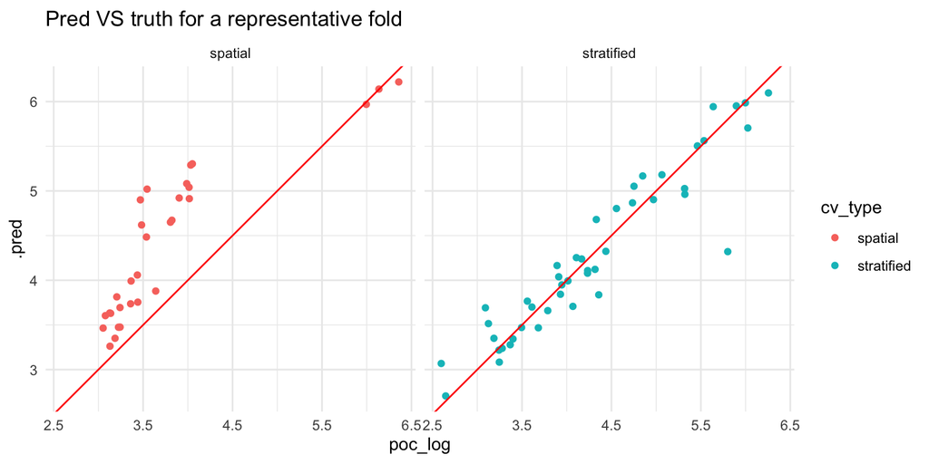

```r
# Find the one closer to the median and plot it
repres_fold <- rsquares %>%
  group_by(cv_type) %>%
  mutate(diff = abs(.estimate - median(.estimate))) %>%
  filter(diff == min(diff)) %>%
  slice_head(n = 1)

repres_fold %>%
  select(cv_type, fold) %>%
  left_join(preds, by = join_by(cv_type, fold)) %>%
  ggplot() +
  geom_point(aes(x = poc_log, y = .pred, colour = cv_type)) +
  geom_abline(intercept = 0, slope = 1, colour = "red") +
  coord_fixed() +
  labs(title = "Pred VS truth for a representative fold") +
  facet_grid(~cv_type)
```

### Variable importance

Variable importance for each fold of each CV type.

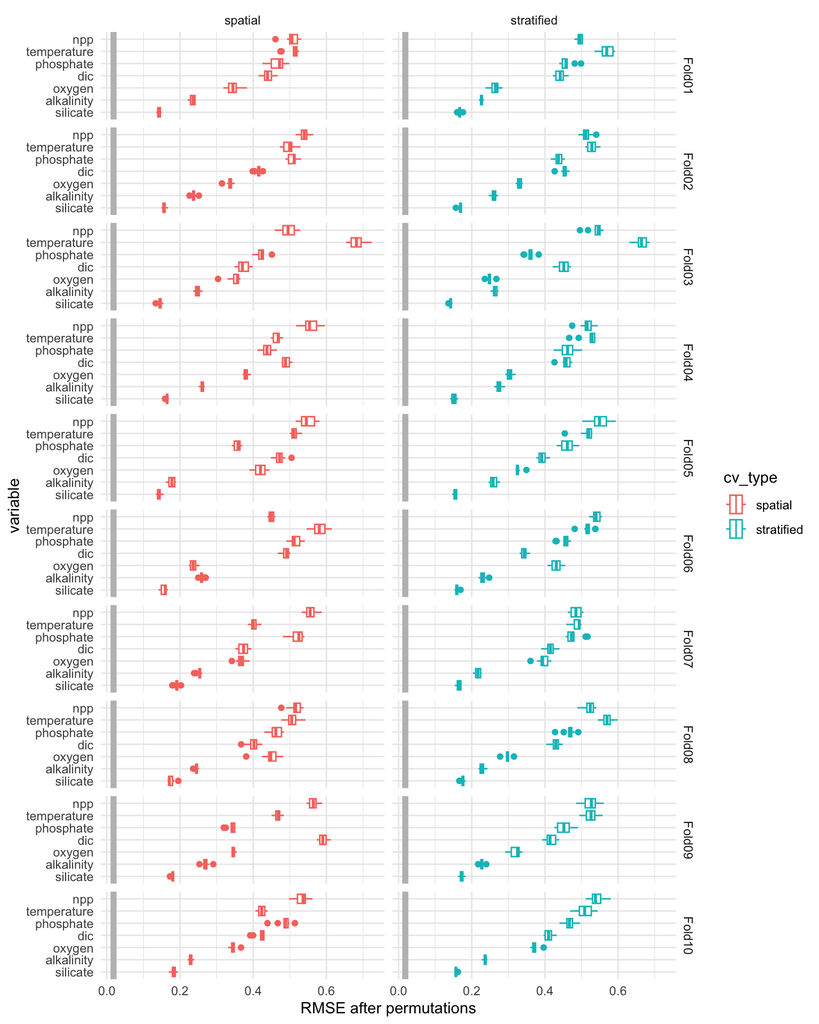

```r
# Unnest variable importance
full_vip <- res %>%
  select(cv_type, fold, importance) %>%
  unnest(importance) %>%
  mutate(variable = forcats::fct_reorder(variable, dropout_loss))

# Variable importance across folds
full_vip %>%
  filter(variable != "_full_model_") %>%
  ggplot() +
  geom_vline(data = full_vip %>% filter(variable == "_full_model_"), aes(xintercept = mean(dropout_loss)), colour = "grey", linewidth = 2) +
  geom_boxplot(aes(x = dropout_loss, y = variable, colour = cv_type)) +
  labs(x = "RMSE after permutations") +
  facet_grid(fold~cv_type)
```

Now let’s take the mean across folds of each CV type.

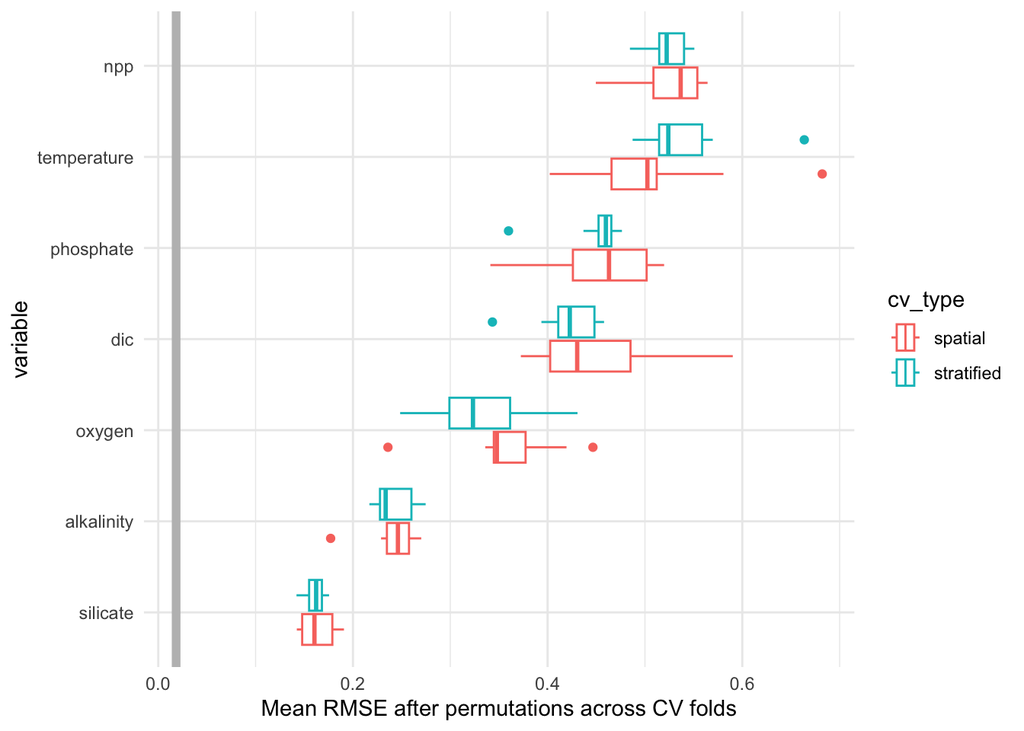

```r
full_vip %>%
  filter(variable != "_full_model_") %>%
  group_by(cv_type, fold, variable) %>%
  summarise(dropout_loss = mean(dropout_loss), .groups = "drop") %>%
  ggplot() +
  geom_vline(data = full_vip %>% filter(variable == "_full_model_"), aes(xintercept = mean(dropout_loss)), colour = "grey", linewidth = 2) +
  geom_boxplot(aes(x = dropout_loss, y = variable, colour = cv_type)) +
  labs(x = "Mean RMSE after permutations across CV folds")
```

### Partial dependence plots

Finally, let’s have a look at partial dependence plots.

- blue line: prediction mean across *cp* profiles
- grey ribbon: prediction sd across centered *cp* profiles

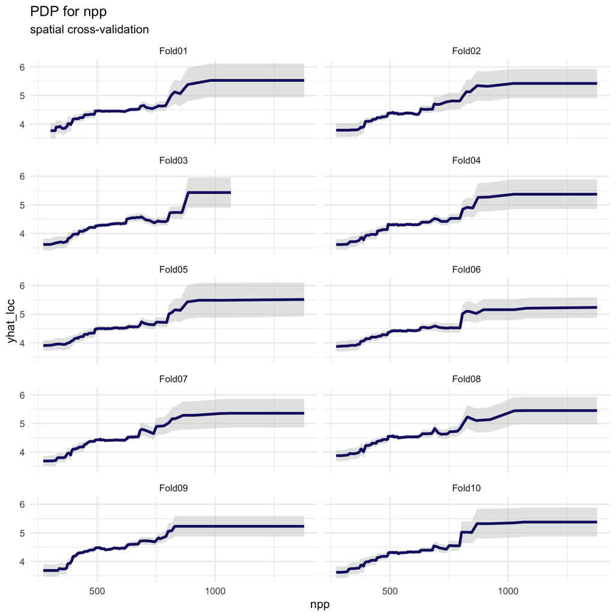

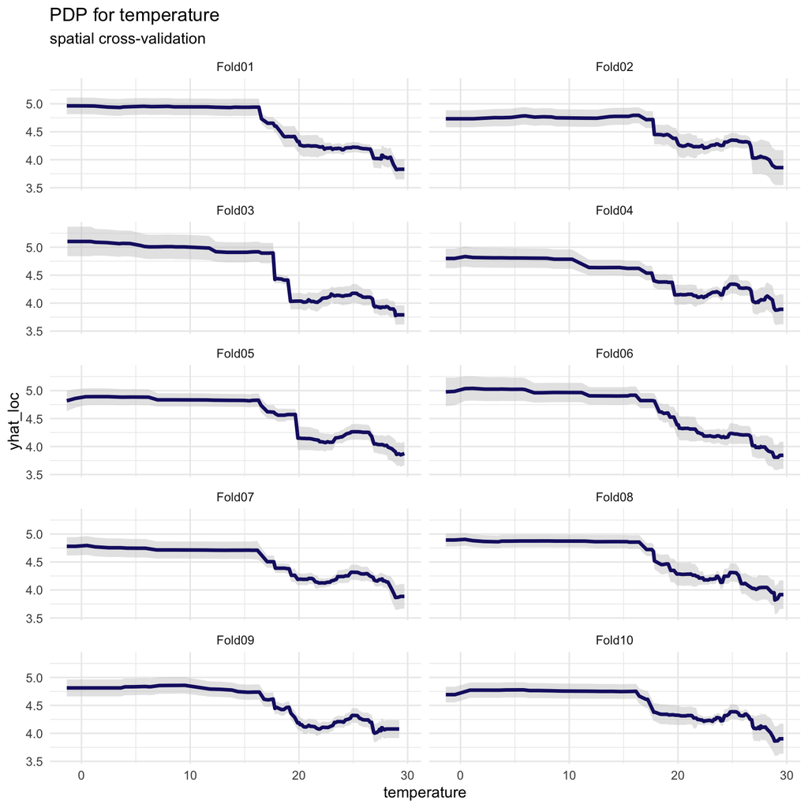

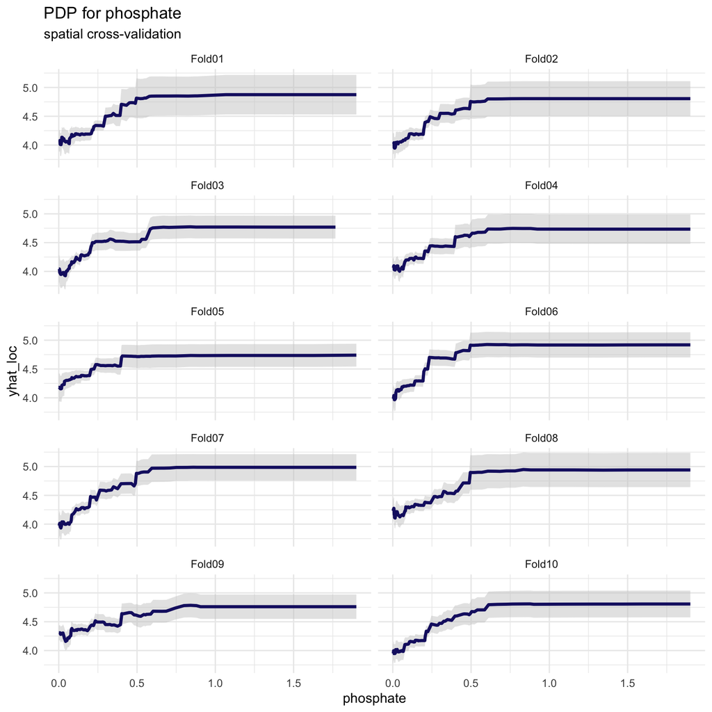

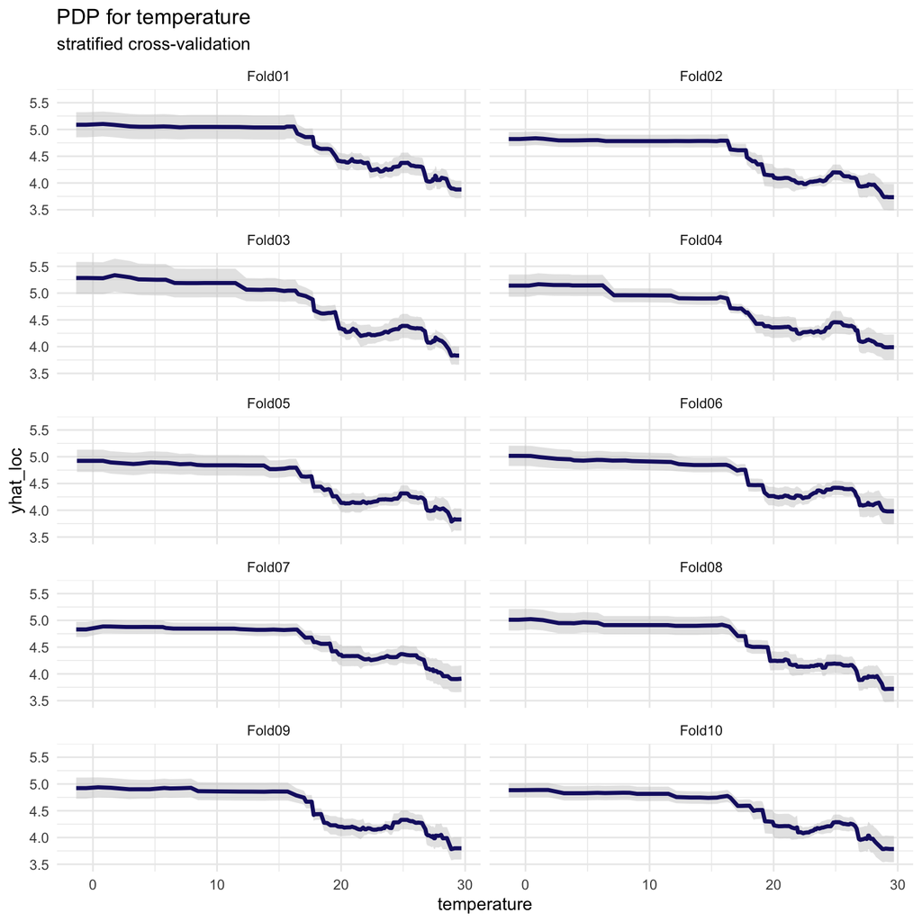

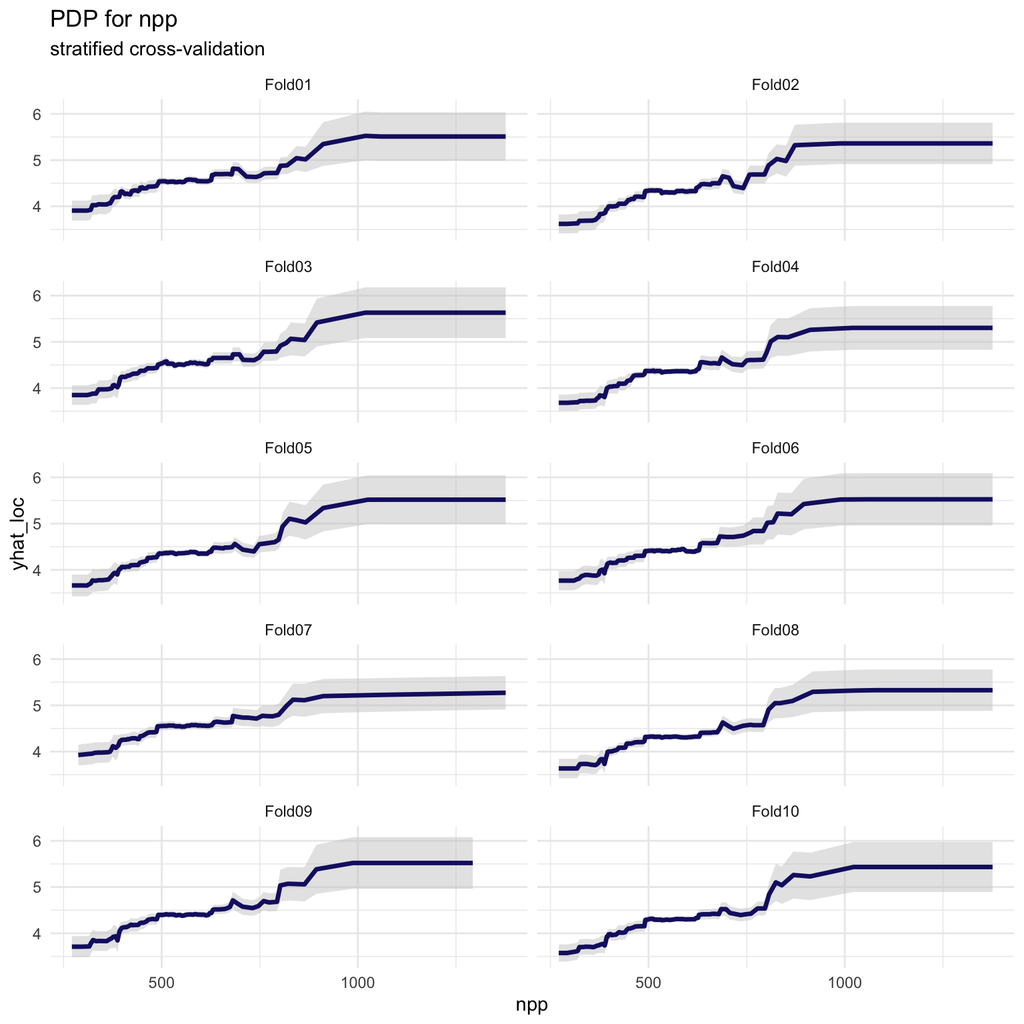

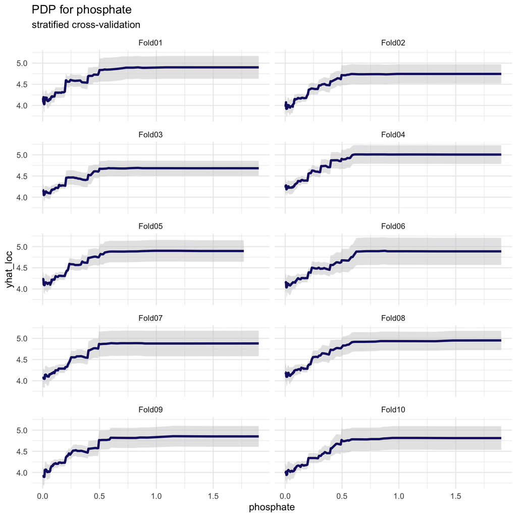

```r
# Variables for which to plot pdp
n_pdp <- 3
vars_pdp <- full_vip %>%
  filter(variable != "_full_model_") %>%
  mutate(variable = as.character(variable)) %>%
  group_by(cv_type, variable) %>%
  summarise(dropout_loss = mean(dropout_loss), .groups = "drop") %>%
  arrange(desc(dropout_loss)) %>%
  group_by(cv_type) %>%
  slice_head(n = n_pdp)

# Unnest cp_profiles
cp_profiles <- res %>% select(cv_type, fold, cp_profiles) %>% unnest(cp_profiles)

# plots
pdp_plots <- lapply(1:nrow(vars_pdp), function(i){
  # Get variable and fold to plot
  x <- vars_pdp[i, ]

  cp_profiles %>%
    # filter for given fold and variable
    filter(cv_type == x$cv_type & `_vname_` == x$variable) %>%
    # center each cp profiles across fold, variable and ids
    group_by(fold, `_vname_`, `_ids_`) %>%
    mutate(yhat_cent = `_yhat_` - mean(`_yhat_`)) %>% # center cp profiles
    ungroup() %>%
    # compute mean and sd of centered cp profiles for each fold and value of the variable of interest
    group_by(fold, across(all_of(x$variable))) %>%
    summarise(
      yhat_loc = mean(`_yhat_`), # compute mean of profiles
      yhat_spr = sd(yhat_cent), # compute sd of cp profiles
      .groups = "keep"
    ) %>%
    ungroup() %>%
    # sort by increasing value of variable of interest
    arrange(across(all_of(x$variable))) %>%
    # rename
    setNames(c("fold", "x", "yhat_loc", "yhat_spr")) %>%
    ggplot() +
    geom_ribbon(aes(x = x, ymin = yhat_loc - yhat_spr, ymax = yhat_loc + yhat_spr), fill = "gray80", alpha = 0.5) +
    geom_path(aes(x = x, y = yhat_loc), color = "midnightblue", linewidth = 1.2) +
    labs(x = x$variable, title = paste("PDP for", x$variable), subtitle = paste(x$cv_type, "cross-validation")) +
    facet_wrap(~fold, ncol = 2)
})
pdp_plots
```